# Transcriptómica espacial de datos de cerebro

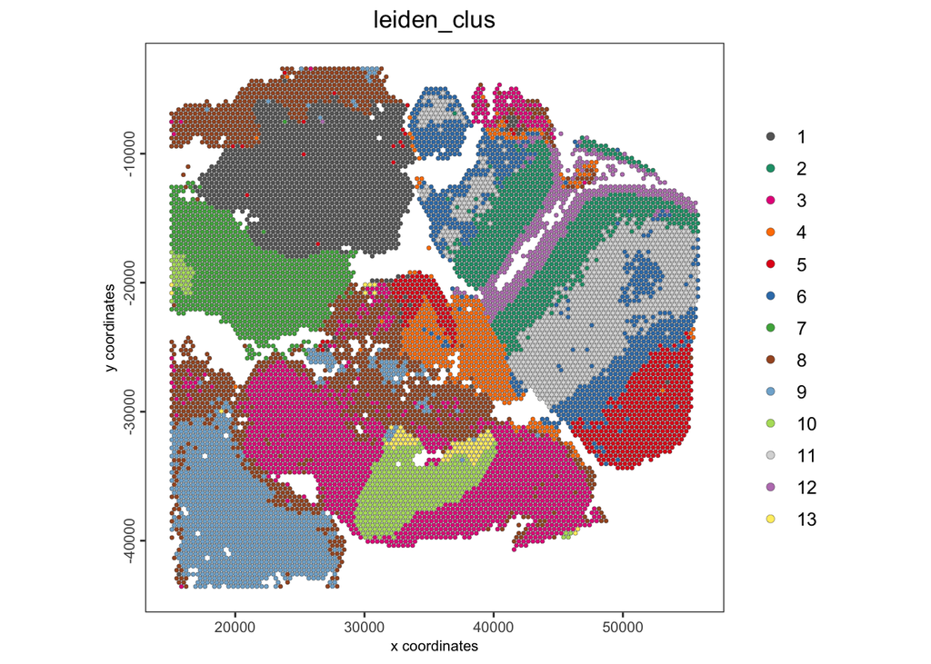

```r
#mantiene el espacio del tejido y agrupa con colores y dice que tan similares son en su perfil
spatPlot2D(visium_brain,
           cell_color = "leiden_clus", #pinta cada spot con el color de su cluste
           point_size = 1, #ajusta el tamaño visual de los puntos en la gráfica
           coord_fix_ratio = 1) #mantiene la misma escala en ambos ejes para que no se distorsione
```

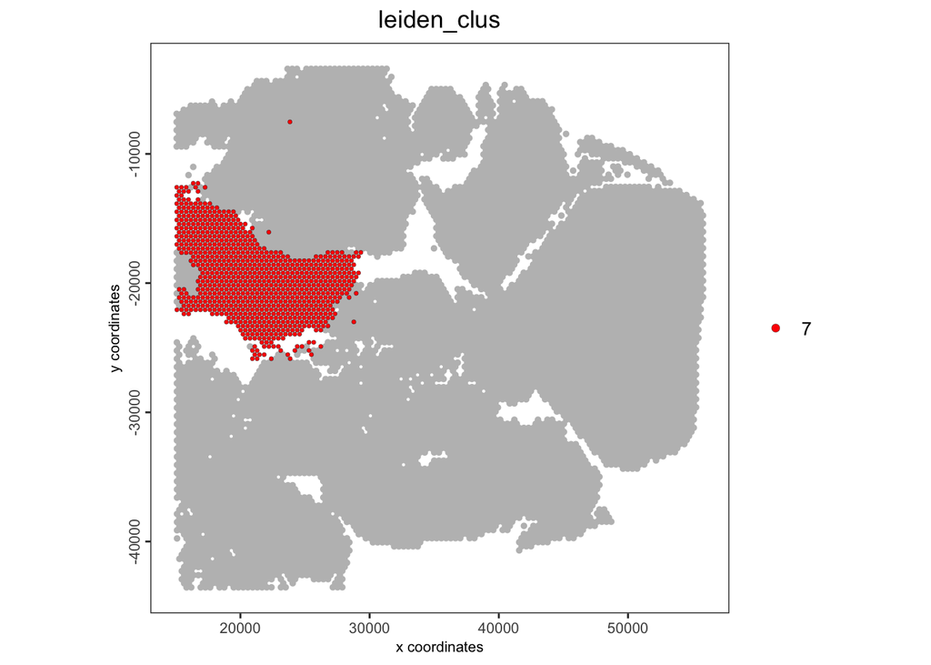

```r
#cada cluster represneta un perfil transcripcional diferente, es la anatomia celular de nuestro cerebro

# Podemos resaltar un grupo de interés
#un ejemplo de como resaltar un cluster en este caso el 7 porque es el que vemos que tiene una mayor expresión de genes:
spatPlot2D(visium_brain,
           cell_color = "leiden_clus",
           select_cell_groups = "7",
           point_size = 1,
           coord_fix_ratio = 1,
           show_other_cells = TRUE,
           cell_color_code = c("7" = "red"),
           other_cell_color = "grey")
```

## 16 Conclusión

Pudimos concluir que en general los datos poseen una buena calidad, debido al filtrado de spots que se mantuvo consistente.

También, es conveniente utilizar grupos de covarianza para identificar los genes altamente variables debido a que agrupa los genes por su nivel de expresión, y permite una comparación más precisa respecto a su variación.

Por otro lado, la reducción de dimensionalidad ayuda a observar una separación de los datos, lo cual sería conveniente revisar con la información biológica en un futuro.

El clustering nos permite visualizar 13 grupos, los cuales poseen posiciones claras dentro del tejido. Resultaría interesante observar si dentro de los grupos se puede identificar un tipo celular modificado por el cáncer del paciente.

Una región que nos llamó la atención analizar es la zona 7, donde observamos que había una mayor expresión de genes. Esto nos podría indicar que el tejido tiene una alta complejidad funcional o gran demanda metabólica. Por lo que sería interesante observar la expresión en esa zona.

El análisis futuro con scRNA-seq y enriquecimiento de tipos celulares nos podría dar más información acerca de la estructura y genes expresados dentro de las células del tumor cerebral.